# Results

Chris Adlam

2/11/2020

# Results

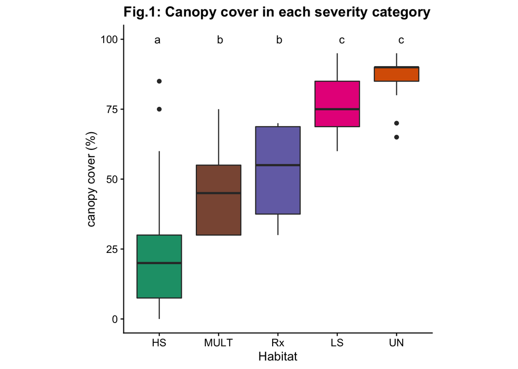

## Comparing community composition by habitat

### Effect of fire history on species composition

First, I take a look at which habitats have similar or different species composition, using a PERMANOVA. For all taxa, there is an effect of habitat (p < 0.001; main PERMANOVA not shown).

Table 1: Pairwise PERMANOVA results

| Pair | plants F_model | plants p_adj | birds F_model | birds p_adj | lichens F_model | lichens p_adj |
| --- | --- | --- | --- | --- | --- | --- |
| HS vs LS | 7.32 | 0.01 | 6.45 | 0.01 | 16.34 | 0.01 |
| HS vs MULT | 3.20 | 0.01 | 1.72 | 0.77 | 25.11 | 0.01 |
| HS vs Rx | 7.43 | 0.01 | 8.11 | 0.01 | 18.11 | 0.01 |
| HS vs UN | 9.95 | 0.01 | 12.06 | 0.01 | 16.46 | 0.01 |
| LS vs MULT | 5.99 | 0.01 | 4.52 | 0.01 | 3.41 | 0.01 |
| LS vs Rx | 6.85 | 0.01 | 6.53 | 0.01 | 6.63 | 0.01 |
| LS vs UN | 2.00 | 0.25 | 2.68 | 0.16 | 1.04 | 1.00 |
| MULT vs Rx | 4.15 | 0.01 | 5.90 | 0.01 | 6.41 | 0.01 |
| MULT vs UN | 6.98 | 0.01 | 8.79 | 0.01 | 3.72 | 0.01 |
| UN vs RX | 5.68 | 0.01 | 8.73 | 0.01 | 7.48 | 0.01 |

### Pairwise habitat comparisons

Using pairwise PERMANOVAs to compare the habitats, there is no detectable difference between plant, bird or lichen communities of LS and UN habitat (Table 1) (plants: p = 0.25; birds: p = 0.16 lichens: p = 1.00). For this reason, from here on I will lump unburnt stands and low severity burns together as UN/LS.

### Species assemblage ordination

The NMDS confirms a considerable overlap in species communities of long-unburnt and low severity burn stands. High severity stands have distinct species communities, while the communities in thinned and burnt stands and multiple burn stands appear to be intermediate between the high severity stands and long-unburnt/low severity stands.

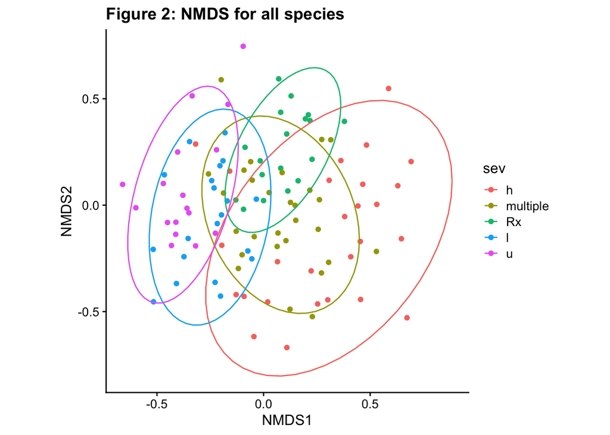

## Alpha, Beta, Gamma diversity patterns

### Alpha diversity

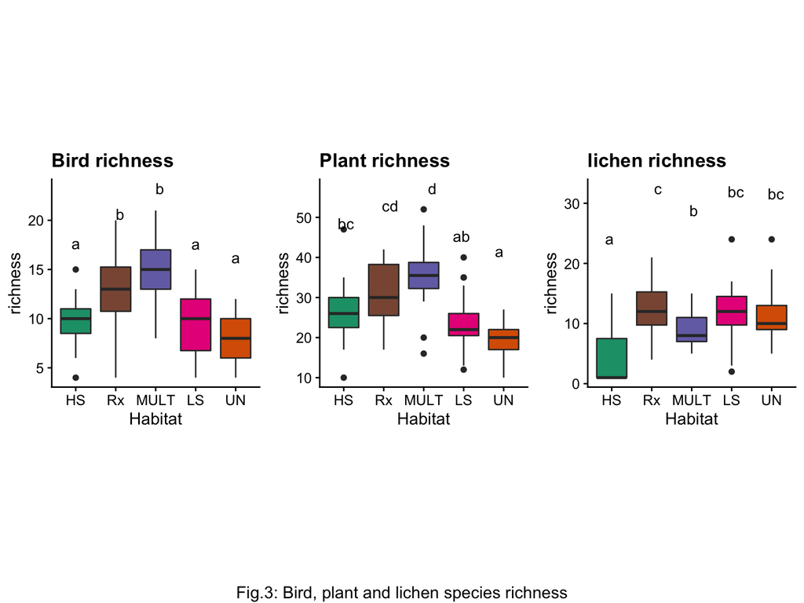

### Beta Diversity

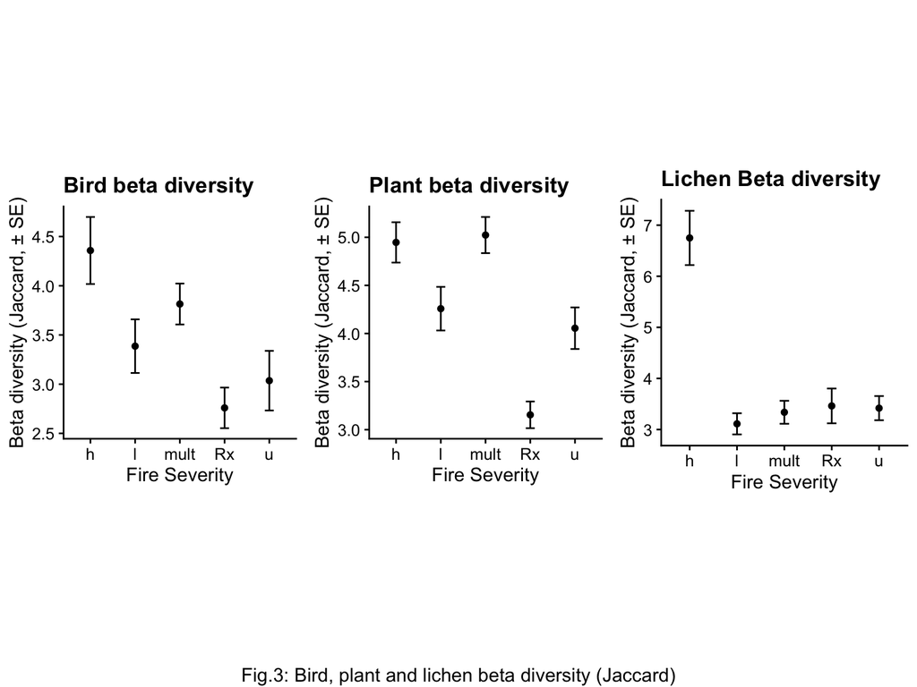

### Gamma diversity and rarefaction curves

I had a different number of samples in each habitat, so instead of presenting simple gamma diversity numbers which would be misleading, I am showing species accumulation curves. The pool of species appears largest in the multiple burns, lowest in the UN/LS stands, and intermediate in the HS burns. For birds, the species pool in the prescribed burn sites is also high, but for plants it levels out faster and is intermediate between the HS and UN/LS sites (however I want to caution against over-interpreting the Rx burn sites, because I had fewer plots and they were more gegraphically clustered).

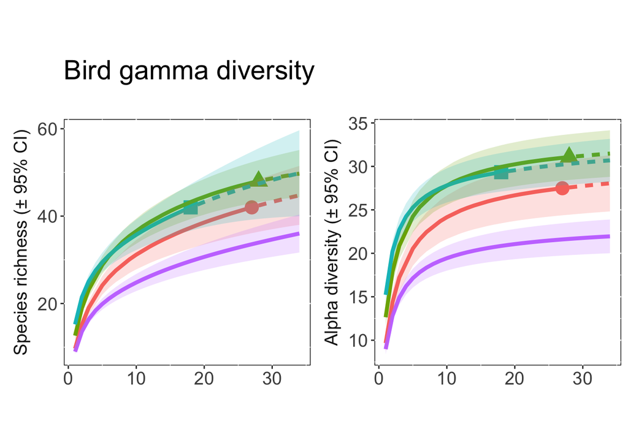

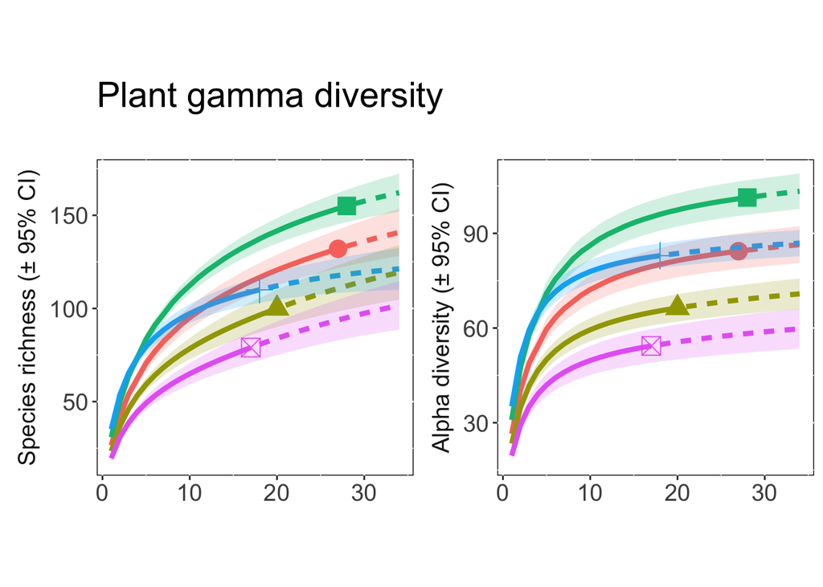

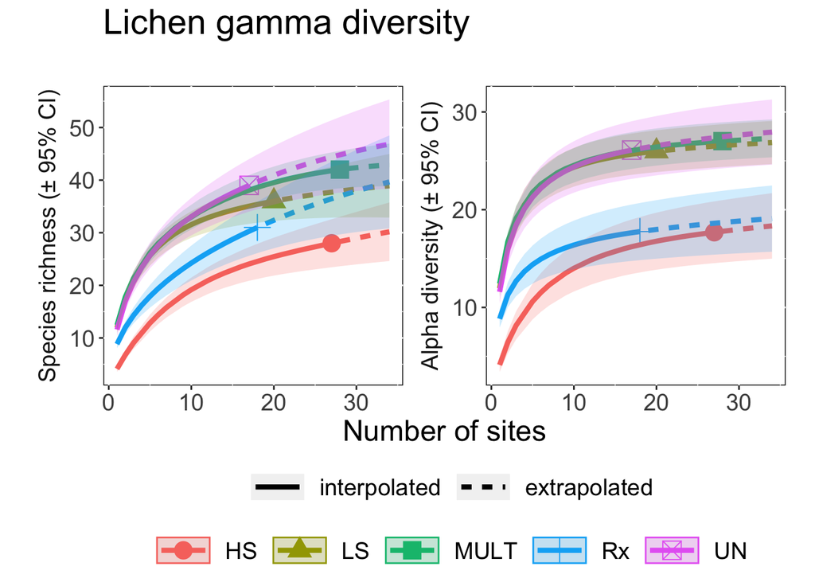

## Insect Indicator Species Analysis

Insect data was analyzed to the order or suborder level (and only for HS, LS and UN habitats). Six taxa were indicator species for the HS habitats. These are mainly pollinators (Aculeata (bees/stinging wasps), Brachyceran flies, Coleoptera), and herbivores (Homoptera, Heteroptera, Orthoptera), which probably reflects the higher abundance of flowers and broadleaf shrubs/trees in HS burns.

```
##
##  Multilevel pattern analysis
##  ---------------------------
##
##  Association function: IndVal.g
##  Significance level (alpha): 0.1
##
##  Total number of species: 13
##  Selected number of species: 6
##  Number of species associated to 1 group: 6
##
##  List of species associated to each combination:
##
##  Group h  #sps.  6
##              stat p.value
## Homoptera   0.909    0.01 **
## Coleoptera  0.872    0.01 **
## Aculeata    0.860    0.02 *
## Brachycera  0.819    0.02 *
## Orthoptera  0.674    0.05 *
## Heteroptera 0.642    0.01 **
## ---
## Signif. codes:  0 '***' 0.001 '**' 0.01 '*' 0.05 '.' 0.1 ' ' 1
```

```
## data frame with 0 columns and 0 rows
```

## Species community composition

Looking at the fequency of occurrence of all plant, bird, and lichen species detected at least 5 times (144 species), I identified species with a strong preference for HS sites or for UN/LS sites. Species were associated with each of these two cohorts if they were found at least twice as frequently in one habitat than in the other. For example, Achillea millefolium (Yarrow) was found in 19% of HS plots and 3% of UN/LS plots; therefore this species was classified as prefering HS stands. Then I determined if these species also favored MULT and/or Rx sites using the same rule. In this case, Achillea millefolium is found in 29% of MULT plots and 28% of Rx plots; because this is also more than twice the UN/LS frequency (3%), I concluded this species also favors MULT and Rx sites.

I identified 61 species (birds, plants and lichens combined) that seem to favor HS, and 45 species that favor UN/LS. What I find is that most species that have a preference for UN/LS or HS are **also** found abundantly in MULT and/or Rx sites: 34 species (76%) prefering UN/LS also favor MULT, while 31 (69%) also favor Rx. Conversely, 49 species (80%) that prefer HS also favor MULT, and 41 (67%) also favor Rx.

Figure 5 breaks down the proportion of plants and birds that prefer HS or UN/LS that also favor MULT and Rx sites.

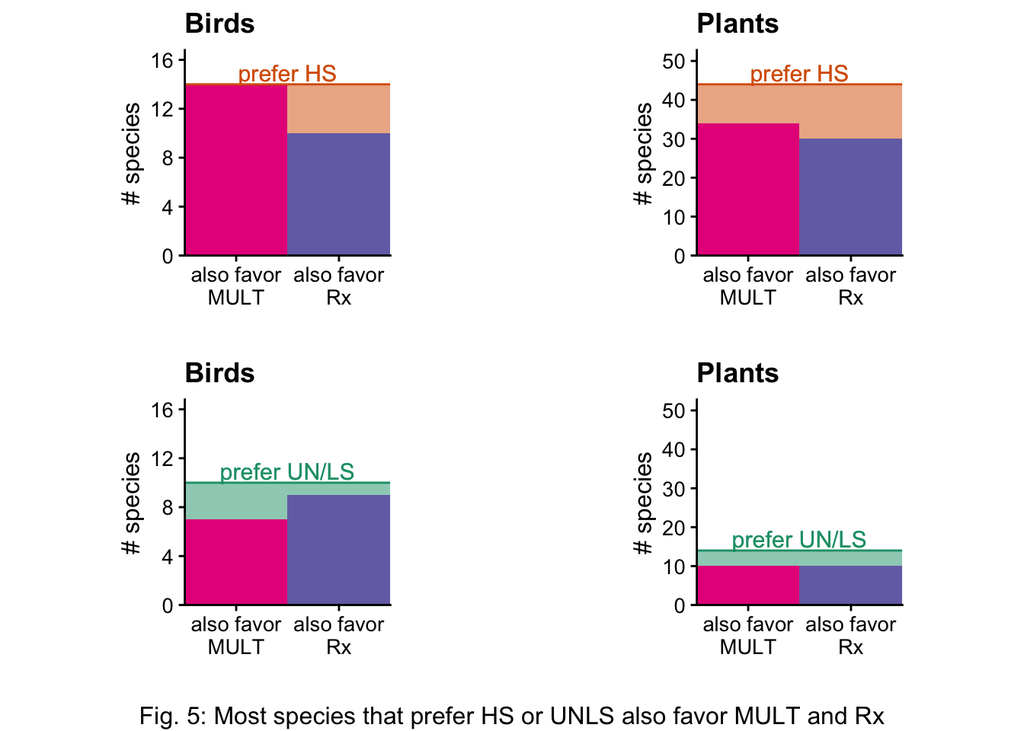